# What’s driving Scotland’s falling reconviction rate?

Ben Matthews and Josiah King

Wednesday 31 July 2019

Last month Scottish Government released the [Reconviction Rates in Scotland statistical bulletin for the 2016/17 cohort](https://www.gov.scot/publications/reconviction-rates-scotland-2016-17-offender-cohort/). One of the headline figures in this bulletin is the *reconviction rate*, calculated as the percentage of offenders who have been reconvicted within follow-up of one year. Last month’s bulletin shows that Scotland’s reconviction rate has fallen steadily over the last fifteen years. Whilst this overall fall in the reconviction rate is undoubtedly good news, in this post we’ll show that interpreting this trend is not as straightforward as it might first seem.

Until 2017 Scottish Government also referred to the average number of reconvictions per offender as the reconviction rate.

This coincided with a fall in [police recorded crime and victimization in Scotland too](http://www.research.aqmen.ac.uk/crime-and-victimisation-research-overview/).

# Reconviction rates and baseball batting averages

There are two factors complicating how we understand this overall decline in the reconviction rate.

First, the reconviction rate has not fallen for all demographic groups, as we can see from Figure One. For example, the reconviction rate for women over the age of 30 has increased, despite the overall fall in the reconviction rate.

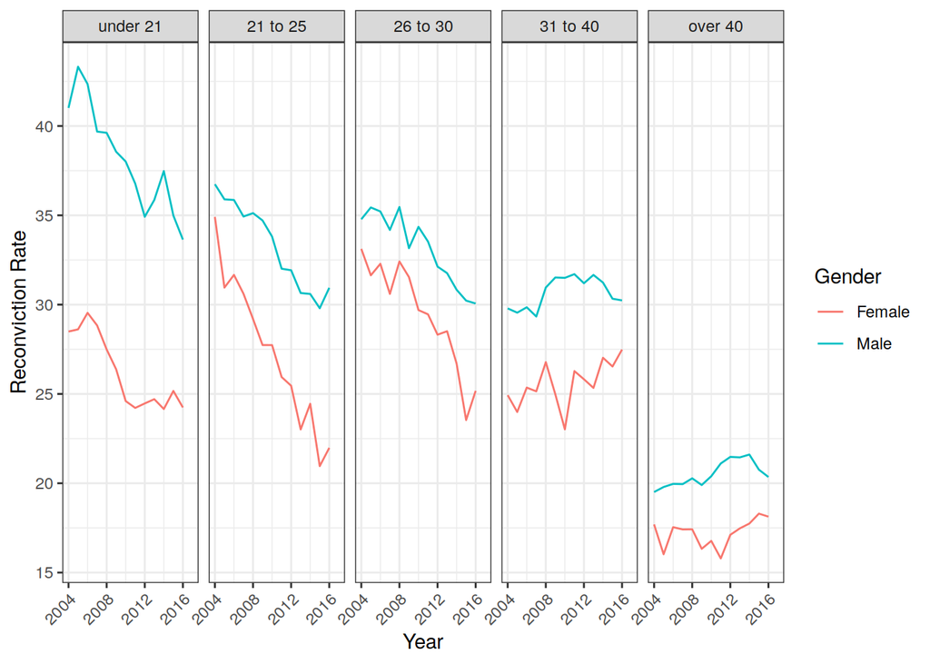

Second, as well as a fall in reconviction rates we’ve also seen substantial changes in numbers of men and women of different ages convicted (known as the *prevalence* of conviction), with very pronounced falls in convictions for young people, and young men in particular, that are not seen in other groups.

Ben wrote about these long-term differences in conviction rates in Scotland by age and sex with Jon Minton [here](http://journals.sagepub.com/doi/abs/10.1177/1477370817731706).

Whilst these two observations may seem unrelated, these divergent trends in the prevalence of conviction have a knock-on effect on the reconviction rate because they affect the proportions of people of different ages who are convicted in a given year (what we’ll call the ‘offender mix’). The ‘offender mix’ can influence the overall reconviction rate *even if the reconviction rates don’t change for any age group*. This is because different age and sex groups typically have different reconviction rates (as we saw in Figure One).

This term is a not-very-elegant shorthand; not all people who commit offences are convicted, and not all people who are convicted have comitted offences.

Typically young people will be convicted at higher rates than older people, and men at higher rates than women.

As the overall reconviction rate the is just average of the reconviction rates for each group, *weighted by the size of the group*, changes in the offender mix can affect the overall reconviction rate, without groups’ reconviction rates changing at all. For example, if women over 40, who have a low average reconviction rate, made up a larger proportion of all people convicted then the overall reconviction rate would go down, even if the reconviction rate itself did not change for any age group. This confusing phenomenon is related to a statistical effect known as Simpson’s paradox, and has been identified in places as diverse as statistics on [kidney-stone removals](https://en.wikipedia.org/wiki/Simpson%27s_paradox#Kidney_stone_treatment) to [baseball batting averages](https://en.wikipedia.org/wiki/Simpson%27s_paradox#Batting_averages).

One implication of this effect is that the fall in the reconviction rate is not only a measure of changes in reoffending - it also reflects changes in the mix of people coming into the justice system (i.e. being convicted) in the first place. The Scottish Government reconvictions bulletin refers to the fall in youth convictions being “significant driver in the reduction in the overall national reconviction rate”, but it is difficult to know exactly how much of the headline declining reconviction rate is due to reductions in reoffending, and how much is due to these changes in offender mix.

## What can we do about it?

We can work around this issue by using methods developed by demographers to apportion the amount of change in the reconviction rate that is due to actual reductions in reoffending and how much is due to changes in the mix of people convicted. Specifically, we use Prithwith Das Gupta’s specification of two techniques known as *standardization* and *decomposition*.

The code and data used for our analysis are available [here](https://github.com/josiahpjking/decomposition_standardisation). We also provide an implementation of Das Gupta’s methods of standardization and decomposition in an R package: DasGuptR [(work in progress)](https://github.com/josiahpjking/DasGuptR)).

As set out in his 1993 book *[Standardization and decomposition of rates: A user’s manual](https://babel.hathitrust.org/cgi/pt?id=osu.32437011198450)*.

Standardization shows us what the reconviction rate would have been under different scenarios - for example, if there was no change in the proportions of different demographic groups entering the justice system and only the prevalence of reconviction had changed. Decomposition gives us the percentage of the difference in rates between two years attributable to each of the factors we have included in the standardization.

## Results

Applying these methods to Scottish Government’s reconvictions data gives us the standardized rates in Figure Two. The green line shows what the reconviction rate would have been if only the offender mix had changed, and the orange line what the reconviction rate would look like if only the prevalence of reconviction had changed. The changing offender mix has played a role in reducing the overall reconviction rate.

You can download the data from https://www.gov.scot/publications/reconviction-rates-scotland-2016-17-offender-cohort/

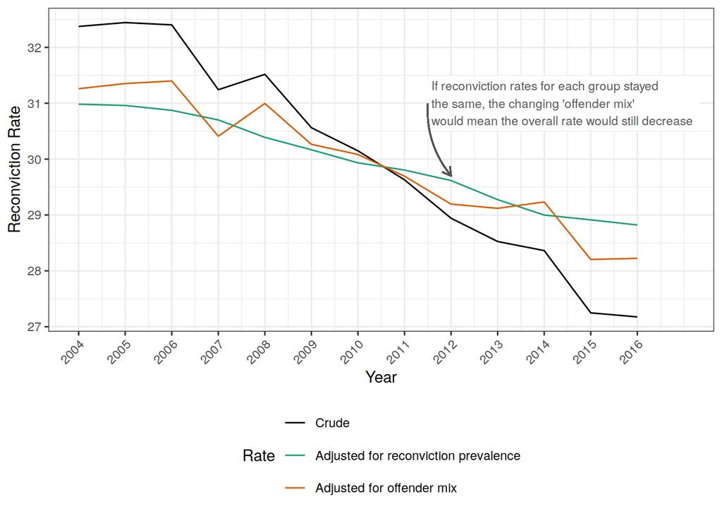

Decomposition allows us to calculate exactly how much of a role the changing age-mix has had in reducing the reconviction rate: 42% of the change in the reconviction rate between 2004 and 2016 is due to the changing offender mix. Standardization and decomposition show us that Scotland’s falling reconviction rate is being driven both by falls in reoffending and by the changing demographic mix of the convicted population.

| Factor | 2004 | 2016 | Difference | Percentage of unadjusted |
| --- | --- | --- | --- | --- |
| Offender mix | 30.98 | 28.82 | 2.16 | 42 |
| Reconviction prevalence | 31.26 | 28.22 | 3.04 | 58 |
| Unadjusted rate | 32.37 | 27.18 | 5.20 | 100 |

## So what?

Our results show how reconviction rates capture not only changes in reconviction patterns, but also changes in the demographic mix of people who are entering the justice system each year.

This is important because it shows how care is needed when interpreting this measure as an evaluation of the support provided to those within the criminal justice system - changes in the reconviction rate in Scotland also reflect falls in youth conviction, perhaps due to changes to youth justice policy which have [emphasised diversion from prosecution](http://scottishjusticematters.com/wp-content/uploads/Shrinking-YJ-population-SJM_5-1_April2017-18.pdf), or broader social changes which may have led to falling youth conviction.

Prior to 2019, another measure - the *average number of reconvictions per offender* - was one of Scottish Governments’ National Indicators, and claimed to be [“one of the main ways of measuring how well we are managing and supporting those that enter our criminal justice system.”](https://www2.gov.scot/About/Performance/scotPerforms/indicator/reconviction). It can be further decomposed into changes in the prevalence and *frequency* of reconvictions as well as the offender mix [(see the DasGuptR worked example)](https://github.com/josiahpjking/DasGuptR).

Ben and Jon Minton discussed the different explanations for the crime drop [here](https://journals.sagepub.com/doi/full/10.1177/1477370817731706#_i2).

This short post has illustrated how tricky it can be to measure outcomes in a complicated and interconnected area like criminal justice. To interpret change in the overall reconvictions rate we need to take account of difference in convictions patterns across both age and sex (and possibly other factors, such as socio-economic status). The Understanding Inequalities project aims to understand how inequalities in Scottish society - like those related to age and sex - intersect, and how they impact on crime and responses to crime. You can find out more about our work on examining crime and inequality in Scotland [here](https://www.understanding-inequalities.ac.uk/research-themes/crime).

For example, in Sweden researchers have shown that there’s a distinct [socio-economic status gradient to the crime drop](http://journals.sagepub.com/doi/full/10.1177/1477370816682979) (NB: This paper is behind a paywall.)